# Implementing data poor methods for Southern hake

Marta Cousido-Rocha, Santiago Cerviño and M. Grazia Pennino

2022-06-27

In data-poor situations length-based methods and surplus production models have been widely applied to understand the dynamics of marine stocks. In this study we evaluate the status of the southern European hake (*Merluccius merluccius*) stock, in the International Council for the Exploration of the Sea (ICES) divisions 27.8.c and 27.9.a, using the following methods: **(1)** the length-based indicators (**LBI**), **(2)** the length-based spawning potential ratio (**LBSPR**), **(3)** the mean length-based mortality estimators (**MLZ**), **(4)** stochastic surplus production model in continuous time (**SPiCT**) and **(5)** known biomass production model (**KBPM**).

# 1 Length Based Indicators (LBI)

## 1.1 Description

A set of length-based indicators was selected for screening catch/landings–length composition and classify the stocks according to conservation/sustainability, yield optimization and Maximum Sustainable Yield (MSY) considerations. These indicators require data on the stock catch/landings–length composition and life-history parameters. The methodology was developed by WKLIFE V (2015), although it had already been previously defined by Froese (2004).

Length-based indicators are calculated by year from length–frequency distributions. They are compared to appropriate reference points related to conservation, optimal yield and length distribution relative to expectations under MSY assumptions.

It is one of the methods recommended by ICES to estimate MSY reference points for stocks of category 3 and 4 (ICES, 2018).

Length-based indicators to assess the state of exploitation of stocks

| Indicator | Calculation | Reference | IndicatorRatio | ExpectedValue | Property |
| --- | --- | --- | --- | --- | --- |
| Lmax5% | Mean length of largest 5% | Linf | Lmax5% / Linf | > 0.8 | Conservation (large individuals) |
| L95% | 95th percentile | Linf | L95% / Linf | > 0.8 |  |
| Pmega | Proportion of individuals above Lopt + 10% | 0.3-0.4 | Pmega | > 0.3 |  |
| L25% | 25th percentile of length distribution | Lmat | L25% / Lmat | > 1 | Conservation (immatures) |
| Lc | Length at first catch (length at 50% of mode) | Lmat | Lc / Lmat | > 1 |  |
| Lmean | Mean length of individuals > Lc | Lopt = 2/3 Linf | Lmean/Lopt | +- 1 | Optimal yield |
| Lmaxy | Length class with maximum biomass in catch | Lopt = 2/3 Linf * | Lmaxy / Lopt | +-1 |  |
| Lmean | Mean length of individuals > Lc | LF=M = (0.75Lc+0.25Linf)* | Lmean / LF=M | >=1 | MSY |

* assuming M/K=1.5

For M/k != 1.5:

$L_{opt} = 3*L_{inf}/(3+(M/k))$

$L_{F=M} = (1-a)*L_c + a*L_{inf}$ a=1/(2*(M/k)+1)

## 1.2 Data required

Information required includes length at maturity ($L_{mat}$, also denoted by $L_{50}$), von Bertalanffy growth parameters ($L_{inf}$), catch at length per year, length–weight relationship parameters ($a$ and $b$) or mean weights-at-length per year and ratio of natural mortality to von Bertalanffy growth rate ($M/k$).

## 1.3 Assumptions

In order to interpret and discuss correctly the results provided by the LBI method is crucial to take into account that it assumes equilibrium conditions (total mortality and recruitment have been constant for a period as long as the years for which its length frequency distribution has been used to apply the method) and logistic selectivity curve (i.e. the curve is flat-topped not dome-shaped).

## 1.4 Loading and plotting data

Loading catch at length per year:

```r
freq <- read.csv(paste(dir,"/Codes and data/LFDs.csv",sep=""), stringsAsFactors = FALSE)

head(freq)
```

```
##   MeanLength X2010 X2011 X2012 X2013 X2014 X2015   X2016 X2017 X2018 X2019
## 1        1.5     0     0     0     0     0     0     0.0     0     0     0
## 2        2.5     0     0     0     0     0     0     0.0     0     0     0
## 3        3.5     0  6928    66     0     0     0     0.0     0     0     0
## 4        4.5     0     0     0     0     0     0     0.0     0     0     0
## 5        5.5     0     0     0     0  7173     0     0.0     0     0     0
## 6        6.5     0  4594     0     0  7173     0 11575.4 31304     0 13594
##      X2020    X2021
## 1    0.000     0.00
## 2    0.000     0.00
## 3    0.000     0.00
## 4    0.000     0.00
## 5    0.000     0.00
## 6 9286.875 11909.23
```

```r
tail(freq)
```

```
##     MeanLength X2010 X2011 X2012 X2013 X2014 X2015 X2016 X2017 X2018 X2019
## 124      124.5     0     0     0     0   0.0    17     0     0     0     0
## 125      125.5     0     0     0     0   0.0     0     0     0     0     0
## 126      126.5     0     0     0     0   0.0     0     0     0     0     0
## 127      127.5     0     0     0     0   0.0     0     0     0     0     0
## 128      128.5     0     0     0     0   0.0     0     0     0     0     0
## 129      129.5     0     0     0     0  51.9     0     0     0     0     0
##     X2020 X2021
## 124     0     0
## 125     0     0
## 126     0     0
## 127     0     0
## 128     0     0
## 129     0     0
```

Loading mean weights-at-length per year:

```r
wal <- read.csv(paste(dir,"/Codes and data/weights.csv",sep=""), stringsAsFactors = FALSE)

head(wal)
```

```
##   MeanLength        X2010        X2011        X2012        X2013        X2014
## 1        1.5 1.362211e-05 1.362211e-05 1.362211e-05 1.362211e-05 1.362211e-05
## 2        2.5 6.872564e-05 6.872564e-05 6.872564e-05 6.872564e-05 6.872564e-05
## 3        3.5 1.995678e-04 1.995678e-04 1.995678e-04 1.995678e-04 1.995678e-04
## 4        4.5 4.424747e-04 4.424747e-04 4.424747e-04 4.424747e-04 4.424747e-04
## 5        5.5 8.356085e-04 8.356085e-04 8.356085e-04 8.356085e-04 8.356085e-04
## 6        6.5 1.418607e-03 1.418607e-03 1.418607e-03 1.418607e-03 1.418607e-03
##          X2015        X2016        X2017        X2018        X2019        X2020
## 1 1.362211e-05 1.362211e-05 1.362211e-05 1.362211e-05 1.362211e-05 1.362211e-05
## 2 6.872564e-05 6.872564e-05 6.872564e-05 6.872564e-05 6.872564e-05 6.872564e-05
## 3 1.995678e-04 1.995678e-04 1.995678e-04 1.995678e-04 1.995678e-04 1.995678e-04
## 4 4.424747e-04 4.424747e-04 4.424747e-04 4.424747e-04 4.424747e-04 4.424747e-04
## 5 8.356085e-04 8.356085e-04 8.356085e-04 8.356085e-04 8.356085e-04 8.356085e-04
## 6 1.418607e-03 1.418607e-03 1.418607e-03 1.418607e-03 1.418607e-03 1.418607e-03
##          X2021
## 1 1.362211e-05
## 2 6.872564e-05
## 3 1.995678e-04
## 4 4.424747e-04
## 5 8.356085e-04
## 6 1.418607e-03
```

```r
tail(wal)
```

```
##     MeanLength    X2010    X2011    X2012    X2013    X2014    X2015    X2016
## 124      124.5 16.38259 16.38259 16.38259 16.38259 16.38259 16.38259 16.38259
## 125      125.5 16.80314 16.80314 16.80314 16.80314 16.80314 16.80314 16.80314
## 126      126.5 17.23101 17.23101 17.23101 17.23101 17.23101 17.23101 17.23101
## 127      127.5 17.66628 17.66628 17.66628 17.66628 17.66628 17.66628 17.66628
## 128      128.5 18.10901 18.10901 18.10901 18.10901 18.10901 18.10901 18.10901
## 129      129.5 18.55928 18.55928 18.55928 18.55928 18.55928 18.55928 18.55928
##        X2017    X2018    X2019    X2020    X2021
## 124 16.38259 16.38259 16.38259 16.38259 16.38259
## 125 16.80314 16.80314 16.80314 16.80314 16.80314
## 126 17.23101 17.23101 17.23101 17.23101 17.23101
## 127 17.66628 17.66628 17.66628 17.66628 17.66628
## 128 18.10901 18.10901 18.10901 18.10901 18.10901
## 129 18.55928 18.55928 18.55928 18.55928 18.55928
```

```
## A blank LB_pars object created
```

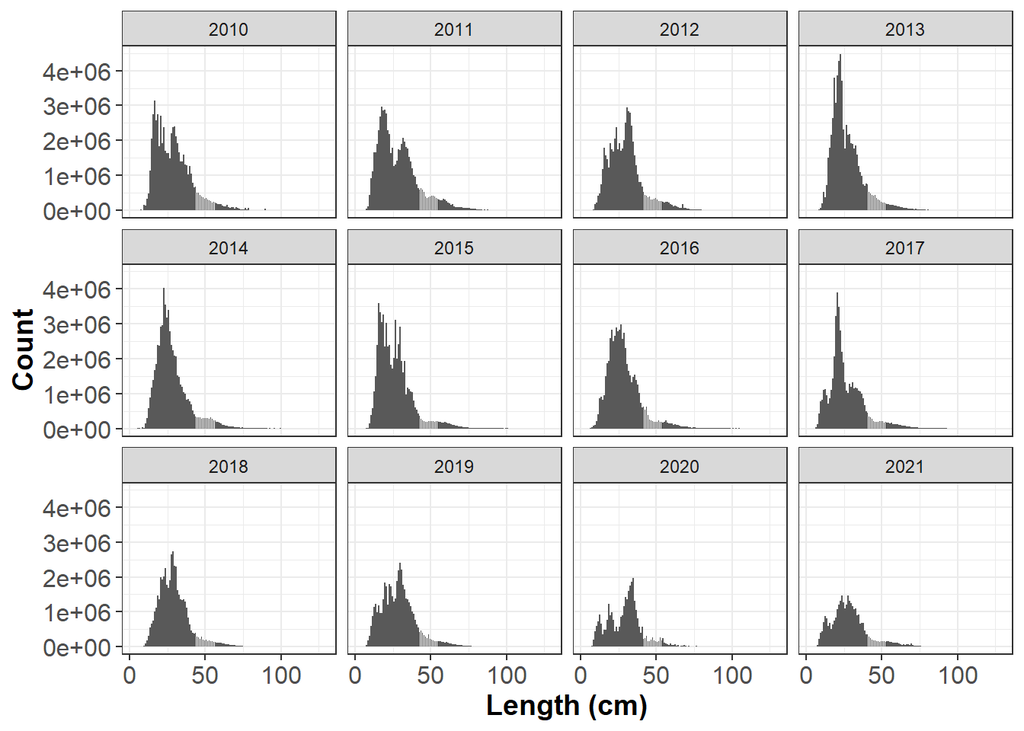

```r
bin_plot(freq, 1, "cm")
```

## 1.5 Life history parameters

- $L_{inf}$ is defined as the mean of the female and male values in the SS model.
- $k$ is defined as the input value in the SS model.
- $M$ is computed as the mean of the $M$ at age values for ages from 0 to 10 (from 10 onwards the population is very reduced).
- $L_{50}$ is the estimated value using a bivariate Bayesian regression model based on female data (SS model input).

```r
Linf_F=110
Linf_M=110*exp(-0.4)
Linf=mean(c(Linf_F,Linf_M))
Linf
```

```
## [1] 91.8676
```

```r
k=0.14

L50=42.36

# Read SS output for obtaining the estimated mortality at age.

load(paste(dir,"/Codes and data/output_SS.RData",sep=""))

M=output$Natural_Mortality_Bmark
M=M[,-c(1:4,16:20)]
M=mean(as.matrix(M))
M
```

```
## [1] 0.4700973
```

## 1.6 Fit

```r
lb_tableSH(freq, 1, "cm", linf=Linf, lmat=L50, mk_ratio=M/k,wal)
```

| Year | Conservation Lc / Lmat | Conservation L25% / Lmat | Conservation Lmax 5 / Linf | Conservation Pmega | Optimizing Yield Lmean / Lopt | MSY Lmean / LF = M |
| --- | --- | --- | --- | --- | --- | --- |
| 2010 | 0.34 | 0.46 | 0.67 | 0.07 | 0.68 | 1.20 |
| 2011 | 0.30 | 0.44 | 0.70 | 0.10 | 0.67 | 1.28 |
| 2012 | 0.37 | 0.51 | 0.66 | 0.08 | 0.71 | 1.21 |
| 2013 | 0.41 | 0.46 | 0.62 | 0.05 | 0.66 | 1.05 |
| 2014 | 0.44 | 0.48 | 0.64 | 0.07 | 0.69 | 1.06 |
| 2015 | 0.34 | 0.41 | 0.65 | 0.06 | 0.63 | 1.11 |
| 2016 | 0.39 | 0.48 | 0.65 | 0.06 | 0.68 | 1.12 |
| 2017 | 0.44 | 0.46 | 0.65 | 0.06 | 0.67 | 1.04 |
| 2018 | 0.44 | 0.53 | 0.64 | 0.06 | 0.71 | 1.10 |
| 2019 | 0.32 | 0.48 | 0.66 | 0.07 | 0.69 | 1.27 |
| 2020 | 0.44 | 0.48 | 0.64 | 0.07 | 0.76 | 1.18 |
| 2021 | 0.30 | 0.48 | 0.69 | 0.08 | 0.68 | 1.30 |

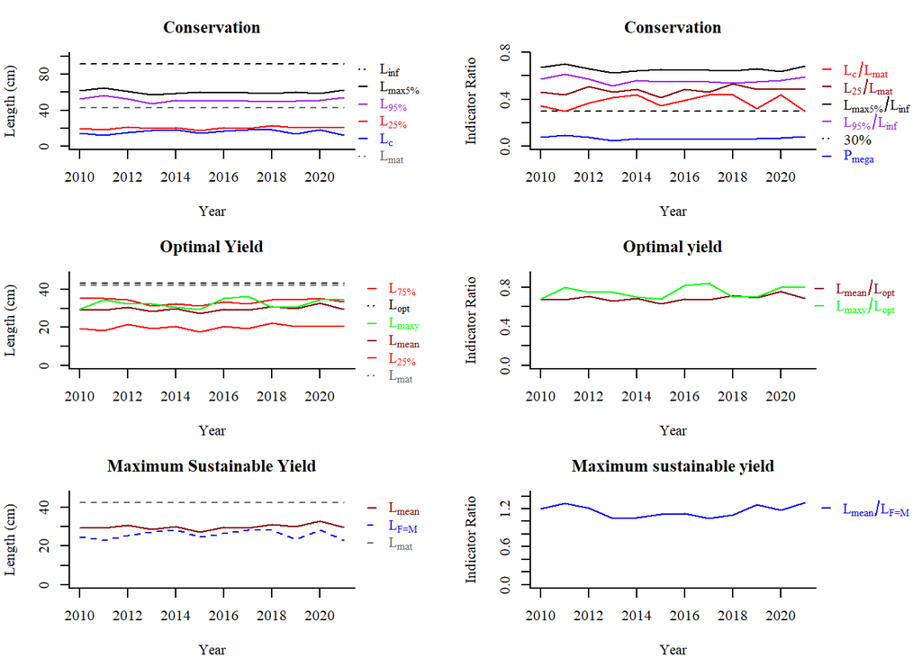

```r
lb_plot(freq, 1, "cm", linf=Linf, lmat=L50, mk_ratio=M/k,wal)
```

## 1.7 Bibliography

Froese, R. (2004). Keep it simple: three indicators to deal with overfishing. Fish and Fisheries, 5 (1): 86-91.

ICES (2015). Report of the Fifth Workshop on the Development of Quantitative Assessment Methodologies based on Life-history Traits, Exploitation Characteristics and other Relevant Parameters for Data-limited Stocks (WKLIFE V), 5-9 October 2015, Lisbon, Portugal. ICES CM 2015/ACOM:56.

ICES (2018). ICES reference points for stocks in categories 3 and 4. ICES Technical Guidelines. Available at: <http://ices.dk/sites/pub/Publication%20Reports/Guidelines%20and%20Policies/16.04.03.02_Category_3-4_Reference_Points.pdf>

# 2 Length Based Spawning Potential Ratio (LBSPR)

## 2.1 Description

What is Spawning Potential ratio (SPR)? - Spawning Potential ratio (SPR) is defined as the proportion of Spawning Biomass per recruit (SBPR) in an exploited stock with regards to SBPR in an unfished (virgin) stock. - The rationale behind is that the abundance at length in the population decreases with ageing (length) because of the mortality (M and F). - A virgin population will have a larger amount of large mature individuals than an exploited population. - The SPR ranges between 1 (virgin population) and 0. - A SPR value between 0.35-0.4 leads usually to consider that the population is exploited at MSY level although this is a quite variable parameter. - A population with SPR value below 0.1-0.15 are considered collapsed.

## 2.2 Data required

The LBSPR data requested are:

- A representative sample of the **size structure of the catch**.
- An understanding of the **life history** of the species. The minimun information required by LBSPR is: maturity-at-size ($L_{50}$ and $L_{95}$, length at 50% and 95% of maturity, respectively), von Bertalanffy growth parameters ($L_{inf}$) and ratio of natural mortality to von Bertalanffy growth rate ($M/k$).

The LBSPR method does not require knowledge of the natural mortality rate (*M*), but instead uses the ratio of natural mortality and the von Bertalanffy growth coefficient (*k*) (*M*/*k*), which is believed to vary less across stocks and species than *M* (Prince et al. 2015).

## 2.3 Assumptions

The LBSPR method assumes that the length composition data is representative of the exploited population at steady state; the selectivity curve is logistic and that the method is equilibrium based (as the LBI method). It also assumes that length composition data comes from the dominant fleet, or that multiple fleets are combined into one composite, and catch-weighted aggregate length composition is derived.

## 2.4 Life history parameters

The values of $L_{inf}$, $M/k$ and $L_{50}$ has been defined previously (LBI Section), now we compute the $L_{95}$ estimate using our logit regression model.

```r
# Coefficients of the logit model
cf=c(-11.242,0.265)
# Function to compute percentiles
lrPerc <- function(cf,p) (log(p/(1-p))-cf[1])/cf[2]
L95=lrPerc(cf,0.95)
L95
```

```
## [1] 53.53373
```

```r
Linf
```

```
## [1] 91.8676
```

```r
M/k
```

```
## [1] 3.357838
```

```r
L50
```

```
## [1] 42.36
```

## 2.5 Fit

```r
Hke1Pars <- new("LB_pars")
Hke1Pars@Linf <- Linf
Hke1Pars@L50 <- L50
Hke1Pars@L95 <- L95
Hke1Pars@MK <- M/k
Hke1Pars@L_units <- "cm"
```

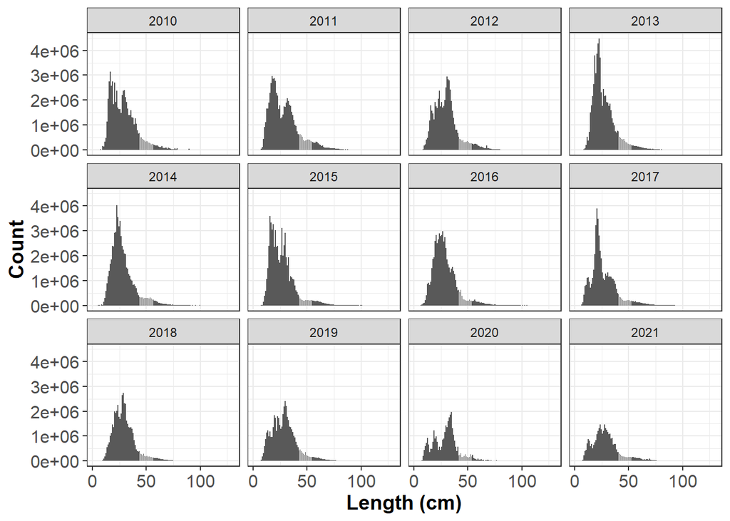

```r
HkeLenFreq1 <- new("LB_lengths", LB_pars=Hke1Pars, file=paste(dir,"/Codes and data/LFDs.csv",sep=""), dataType="freq", header=TRUE)
HkeLenFreq1@L_units <- Hke1Pars@L_units
LBSPR::plotSize(HkeLenFreq1)
```

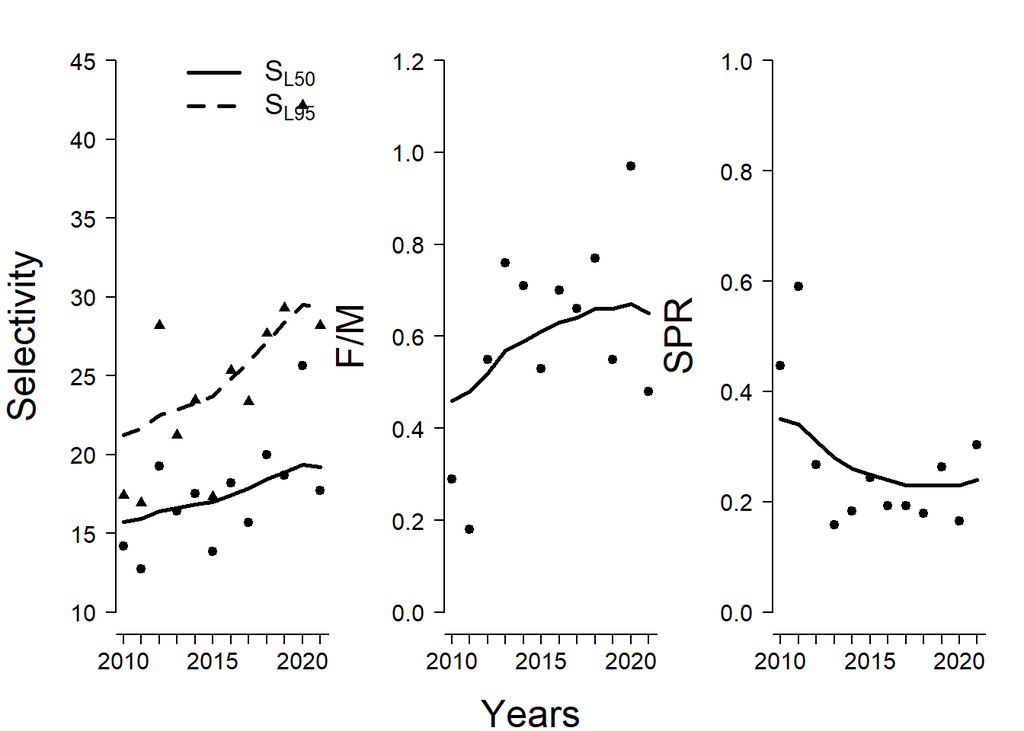

```r
Fit1 <- LBSPRfit(Hke1Pars, HkeLenFreq1, verbose = FALSE)
plotEsts(Fit1)
```

## 2.6 Bibliography

Hordyk, A.R., Ono, K., Sainsbury, K.J., Loneragan, N., and Prince, J.D. (2015a). Some explorations of the life history ratios to describe length composition, spawning-per-recruit, and the spawning potential ratio. ICES J. Mar. Sci. 72: 204 - 216.

Hordyk, A.R., Ono, K., Valencia, S.R., Loneragan, N.R., and Prince, J.D. (2015b). A novel length-based empirical estimation method of spawning potential ratio (SPR), and tests of its performance, for small-scale, data-poor fisheries. ICES J. Mar. Sci. 72: 217 – 231.

Hordyk, A.R., Loneragan, N.R., and Prince, J.D. (2015c). An evaluation of an iterative harvest strategy for data-poor fisheries using the length-based spawning potential ratio assessment methodology. Fish. Res. 171: 20– 32.

Hordyk, A., Ono, K., Prince, J.D., and Walters, C.J. (2016). A simple length-structured model based on life history ratios and incorporating size-dependent selectivity: application to spawning potential ratios for data-poor stocks. Can. J. Fish. Aquat. Sci. 13: 1– 13. doi: 10.1139/cjfas-2015-0422.

Prince, J.D., Hordyk, A.R., Valencia, S.R., Loneragan, N.R., and Sainsbury, K.J. (2015). Revisiting the concept of Beverton–Holt life-history invariants with the aim of informing data-poor fisheries assessment. ICES J. Mar. Sci. 72: 194 - 203.

# 3 Mean length-based mortality estimators (MLZ)

## 3.1 Description

The mean length of animals that are fully vulnerable to the sampling gear can be used to estimate total mortality from basic growth parameters and a known length at first capture. This approach may in some cases represent the best opportunity to reconstruct the mortality history of a stock.

In this study we focus on applied the MLZ method proposed by Then (2018). Previous methods are also described below for context purposes.

- **Beverton-Holt length-based mortality estimator** is widely used in data-limited fish stock assessment, however, the method requires equilibrium conditions. It assumes equilibrium length composition such that the mean length reflects the current $Z$ rate experienced by the stock.
- **Gedamke and Hoenig (2006)** modified the Beverton and Holt estimator by relaxing the strict assumption of equilibrium population. This was done by modelling the transition of mean length from one equilibrium period to the next one, following step-wise changes in Z. Using a time series of mean length observations, the Gedamke- Hoenig estimator yields **period-specific estimates of Z and the corresponding years of change in mortality**.
- **Then et al. (2018)** developed a new formulation of the Gedamke-Hoenig estimator that utilizes **additional information from a time-series of fishing effort** to estimate the catchability coefficient $q$ and the natural mortality rate $M$ and thus **year-specific total and fishing mortality rates**.

## 3.2 Assumptions

Then et al. (2018) method assumes constant fishery recruitment and knife-edge selection of lengths (flat topped selectivity curve) by the fishery gear. Other model assumptions include: mean length at age known and constant over time; no individual variability in growth; natural mortality $M$ independent of stock size and constant with age and over time, and constant catchability $q$ over time and over age for all ages $\geq t_c$ being $t_c$ is the age at which animals are fully vulnerable to the fishery and to the sampling gear.

## 3.3 Data required

Time-series of length measurements, von Bertalanffy growth parameters $L_{\infty}$ and $k$ for the stock, time-series of fishing effort and the so-called length of first capture ($L_c$, i.e., the smallest size at which animals are fully vulnerable to the fishery and to the sampling gear). The effort time-series can be derived as the ratio of the catch and a CPUE series. Additionally to the above data and input parameters, guesses for the maximum age, catchability coefficient and natural mortality rate must be specified.

## 3.4 Preparing data

### 3.4.1 Load packages and useful functions

### 3.4.2 Read data

Introduce stock name and max age.

```r
name <- "Southern hake"
sex <- "Both"
max_age <- 12
```

```r
# LFDs
input_lenfreq <- read.csv(paste(dir,"/Codes and data/LFDs.csv",sep=""))
colnames(input_lenfreq)[1] <- "Length"

# Defining effort:

# Indices (surveys and CPUEs)
input_effort <-read.csv(paste(dir,"/Codes and data/indices 1982-2021.csv",sep=""))

# Use catches and CPUE (spanish one) to define effort time series
input_effort=subset(input_effort,input_effort$index=="SpCPUE_trawlers")
input_effort=subset(input_effort,input_effort$year>=2010)

# Catches
input_catches<-read.csv(paste(dir,"/Codes and data/Tab10.6_init.csv",sep=""))
# Cut years
input_catches=subset(input_catches,input_catches$years>=2010)


effort=input_catches$catch/input_effort$obs
input_effort=cbind(input_effort$year,effort)
colnames(input_effort) <-c("Year", "effort")


input_melt <- reshape2::melt(input_lenfreq, id.vars="Length", variable.name="Year")
input_melt$Year <- as.numeric(substr(input_melt$Year, 2, 5))

head(input_lenfreq)
```

```
##   Length X2010 X2011 X2012 X2013 X2014 X2015   X2016 X2017 X2018 X2019    X2020
## 1    1.5     0     0     0     0     0     0     0.0     0     0     0    0.000
## 2    2.5     0     0     0     0     0     0     0.0     0     0     0    0.000
## 3    3.5     0  6928    66     0     0     0     0.0     0     0     0    0.000
## 4    4.5     0     0     0     0     0     0     0.0     0     0     0    0.000
## 5    5.5     0     0     0     0  7173     0     0.0     0     0     0    0.000
## 6    6.5     0  4594     0     0  7173     0 11575.4 31304     0 13594 9286.875
##      X2021
## 1     0.00
## 2     0.00
## 3     0.00
## 4     0.00
## 5     0.00
## 6 11909.23
```

```r
tail(input_lenfreq)
```

```
##     Length X2010 X2011 X2012 X2013 X2014 X2015 X2016 X2017 X2018 X2019 X2020
## 124  124.5     0     0     0     0   0.0    17     0     0     0     0     0
## 125  125.5     0     0     0     0   0.0     0     0     0     0     0     0
## 126  126.5     0     0     0     0   0.0     0     0     0     0     0     0
## 127  127.5     0     0     0     0   0.0     0     0     0     0     0     0
## 128  128.5     0     0     0     0   0.0     0     0     0     0     0     0
## 129  129.5     0     0     0     0  51.9     0     0     0     0     0     0
##     X2021
## 124     0
## 125     0
## 126     0
## 127     0
## 128     0
## 129     0
```

```r
input_effort
```

```
##       Year    effort
##  [1,] 2010 13173.594
##  [2,] 2011 12680.255
##  [3,] 2012 18295.217
##  [4,] 2013 12772.358
##  [5,] 2014 15751.936
##  [6,] 2015 14689.313
##  [7,] 2016 12347.196
##  [8,] 2017 12614.501
##  [9,] 2018 16286.024
## [10,] 2019  9995.988
## [11,] 2020 11071.428
## [12,] 2021 10681.111
```

### 3.4.3 Histograms and definition of length of full selectivity ($L_c$)

```r
stockname <- paste(name, sex)

par(mfrow=c(1, 1))
input_tot <- rowSums(input_lenfreq[, -1])
input_lengths <- input_lenfreq[,1]

Lc <- input_lengths[which.max(input_tot)] ; Lc
```

```
## [1] 20.5
```

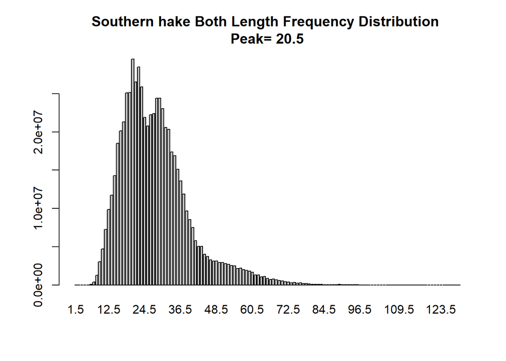

```r
barplot(input_tot, names.arg=input_lengths,
        main=paste(stockname, "Length Frequency Distribution \nPeak=", Lc))
```

### 3.4.4 Calculate annual mean lengths of animals of lengths larger than $L_c$

```r
ml_gh <- neph_Lbar(input=input_melt, Lc=Lc)
ml_gh
```

```
##     Year     mlen ss_bins ss
##  1: 2010 33.51151      78  1
##  2: 2011 34.65951      81  1
##  3: 2012 33.02172      79  1
##  4: 2013 30.37816      83  1
##  5: 2014 30.86112      99  1
##  6: 2015 31.63322      99  1
##  7: 2016 31.39848      97  1
##  8: 2017 30.77537      94  1
##  9: 2018 31.68881      90  1
## 10: 2019 33.00195      92  1
## 11: 2020 34.11320      80  1
## 12: 2021 32.73548      91  1
```

## 3.5 Fit

Note that the initial value of $q$ have been fixed as: 0.6/mean(effort), where 0.6 is a guess for the fishing mortality and mean(effort) is the mean of the time series of effort.

```r
ml_thog <- left_join(as.data.frame(input_effort),
                     (ml_gh),
                     by = "Year")
ml_thog$ss_bins[is.na(ml_thog$ss_bins)] <- 0
ml_thog$ss[is.na(ml_thog$ss)] <- 0
q0=0.6/mean(ml_thog$effort)
```

Below we fir the model fixing $M$,  
$M$ can be also estimated if you change to “T” the argument est.M.

```r
a=mlen_effort(year = ml_thog$Year,
            mlen = ml_thog$mlen,
            effort = ml_thog$effort,
            ss = ml_thog$ss,
            K = k,
            Linf = Linf,
            Lc = Lc,
            n_cohort = 1,
            n_age = max_age,
            init_effort = rep(ml_thog$effort[1], max_age),
            stq = c(q0),
            stM = c(M), est.M = F,graph = FALSE)

a
```

```
## $summary
##   Variable     Estimate      Std.dev
## 1        q 4.489928e-05 0.0003846561
## 2    sigma 4.427286e+01           NA
##
## $convergence
## [1] "Optimizer converged after 29 function calls."
##
## $hessian
## [1] "Hessian matrix is positive definite."
##
## $correlation
## [1] "M is fixed."
##
## $results
##    year observed predicted residual         F
## 1  2010 33.51151         0 33.51151 0.5914849
## 2  2011 34.65951         0 34.65951 0.5693343
## 3  2012 33.02172         0 33.02172 0.8214420
## 4  2013 30.37816         0 30.37816 0.5734697
## 5  2014 30.86112         0 30.86112 0.7072506
## 6  2015 31.63322         0 31.63322 0.6595396
## 7  2016 31.39848         0 31.39848 0.5543802
## 8  2017 30.77537         0 30.77537 0.5663820
## 9  2018 31.68881         0 31.68881 0.7312307
## 10 2019 33.00195         0 33.00195 0.4488127
## 11 2020 34.11320         0 34.11320 0.4970991
## 12 2021 32.73548         0 32.73548 0.4795742
```

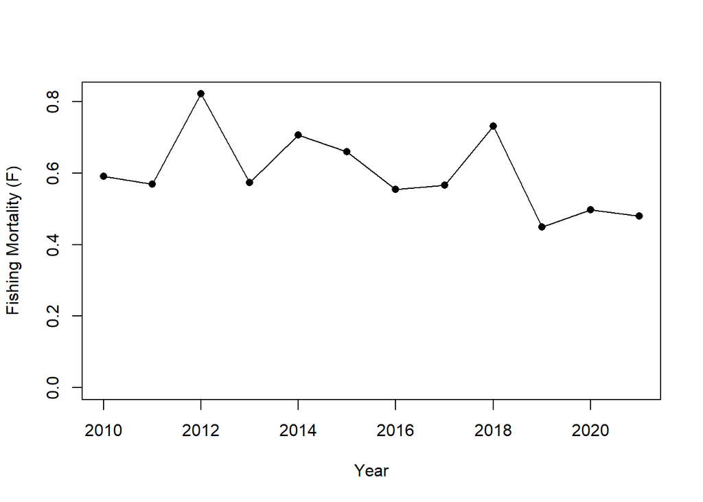

```r
year=2010:2021
plot(year, a$results$F, xlab = "Year", ylab = "Fishing Mortality (F)",
         typ = "o", pch = 16, col = "black",ylim=c(0,max(a$results$F)))
```

## 3.6 References

Gedamke, T., and Hoenig, J.M. (2006). Estimating Mortality from Mean Length Data in Non-equilibrium Situations, with Application to the Assessment of Goosefish. Trans. Amer. Fish. Soc., 135:476–487.

Then, A.Y., Hoenig, J.M., and Huynh, Q.C. (2018). ``Estimating fishing and natural mortality rates, and catchability coefficient, from a series of observations on mean length and fishing effort’’. VIMS Articles. 749. https://scholarworks.wm.edu/vimsarticles/749

# 4 Stochastic surplus production model in continuous time (SPiCT)

## 4.1 Description

SPiCT explicitly models both biomass and fishing dynamics as stochastic processes in a state-space framework. It is formulated as a continuous time model to allow a representation of seasonal fishing behaviour and incorporation of sub-annual catch and index data (see Pedersen and Berg, 2017).

One of the most important inputs for fitting SPiCT is the catch biomass time series (by weight). Additionally, SPiCT requires at least a biomass index to calibrate the population biomass and estimate the model parameters. An important advantage of SPiCT is that it allows the use of multiple biomass indices with different time-series in addition to the catch time series as we can see below.

## 4.2 Load packages

```r
# Uncomment lines if necessary:
# remotes::install_github("tokami/spict/spict", ref="fix130")
# install_github("DTUAqua/spict/spict")
library(spict)
library(readxl)
```

## 4.3 Prepare input data

Loading catches and relative biomass indices.

```r
# Catches
input_catches<-read.csv(paste(dir,"/Codes and data/Tab10.6_init.csv",sep=""))
# Cut years
input_catches=subset(input_catches,input_catches$years>=1982)

# Indices

input_ind <-read.csv(paste(dir,"/Codes and data/indices 1982-2021.csv",sep=""))

I_P=subset(input_ind,input_ind$index=="PtGFS")
I_S=subset(input_ind,input_ind$index=="SpGFS")
ind_SpCPUE_trawlers=subset(input_ind,input_ind$index=="SpCPUE_trawlers")
ind_SpCPUE_volpal=subset(input_ind,input_ind$index=="SpCPUE_volpal")


years_cat=input_catches$years

len_cat=length(years_cat)

inp1 <- list(timeC = years_cat, obsC = input_catches$catch,
            timeI = list(
                         I_P$year+0.86,
                         I_S$year+0.86,
                         ind_SpCPUE_trawlers$year+0.5,
                         ind_SpCPUE_volpal$year+0.5
                         ),
            obsI = list(
                        I_P$obs,
                        I_S$obs,
                        ind_SpCPUE_trawlers$obs,
                        ind_SpCPUE_volpal$obs
                         ))

inp1=check.inp(inp1)
```

```
## Removing zero, negative, and NAs in  I  series  2
```

The data can be plotted using the command:

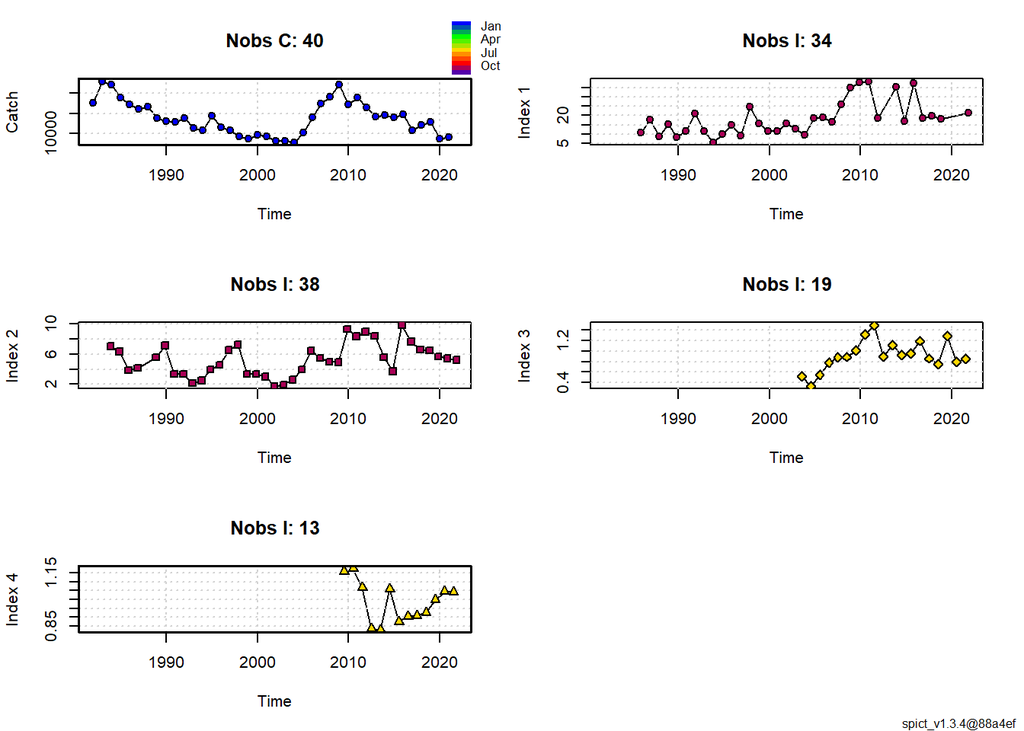

```r
source(paste(dir,"/Codes and data/functions.R",sep=""))
source(paste(dir,"/Codes and data/plotting.R",sep=""))
par(mfrow=c(3,2))
plotspict.data.adp(inp1)
```

```r
c("PtSurv","SpSurv","SpCPUE_trawlers","SpCPUE_volpal")
```

```
## [1] "PtSurv"          "SpSurv"          "SpCPUE_trawlers" "SpCPUE_volpal"
```

## 4.4 Fit

The model is fitted to data by running:

```r
res1 <- fit.spict(inp1)
```

The results are summarized using:

```r
capture.output(summary(res1))
```

```
##  [1] "Convergence: 0  MSG: relative convergence (4)"
##  [2] "Objective function at optimum: 16.2958534"
##  [3] "Euler time step (years):  1/16 or 0.0625"
##  [4] "Nobs C: 40,  Nobs I1: 34,  Nobs I2: 38,  Nobs I3: 19,  Nobs I4: 13"
##  [5] ""
##  [6] "Priors"
##  [7] "     logn  ~  dnorm[log(2), 2^2]"
##  [8] " logalpha  ~  dnorm[log(1), 2^2]"
##  [9] "  logbeta  ~  dnorm[log(1), 2^2]"
## [10] ""
## [11] "Model parameter estimates w 95% CI "
## [12] "            estimate        cilow        ciupp     log.est  "
## [13] " alpha1 2.201881e+00 1.348815e+00 3.594473e+00   0.7893119  "
## [14] " alpha2 2.098969e+00 1.252142e+00 3.518506e+00   0.7414462  "
## [15] " alpha3 1.158104e+00 6.049867e-01 2.216918e+00   0.1467844  "
```

[output cut: 46 more lines]

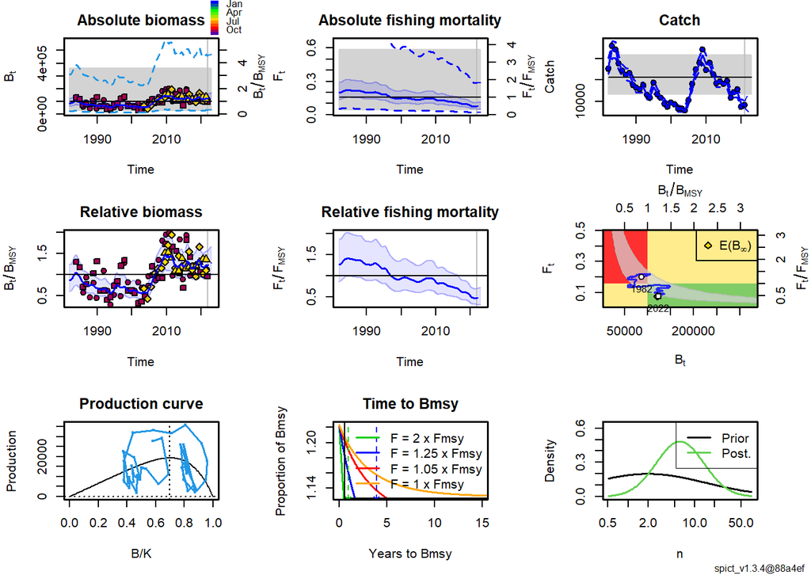

```r
plot(res1,CI = 0.9)
```

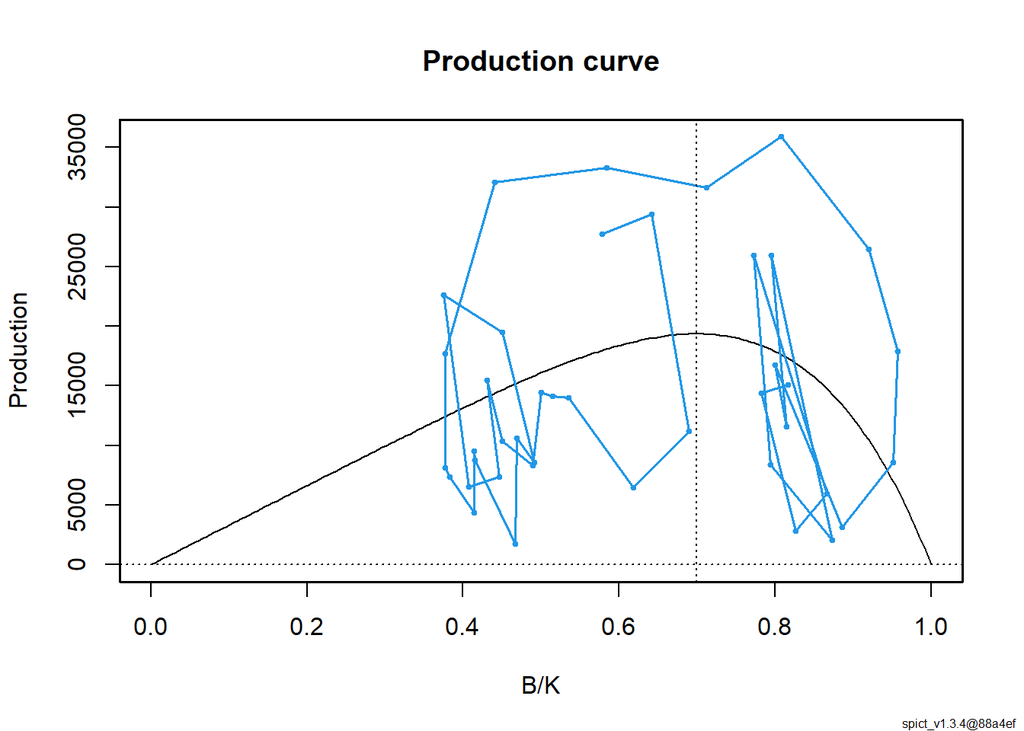

```r
par(mfcol=c(1,1))
plotspict.production(res1)
```

**Checklist for the acceptance of a SPiCT assessment**

```r
res1$opt$convergence
```

```
## [1] 0
```

```r
all(is.finite(res1$sd))
```

```
## [1] TRUE
```

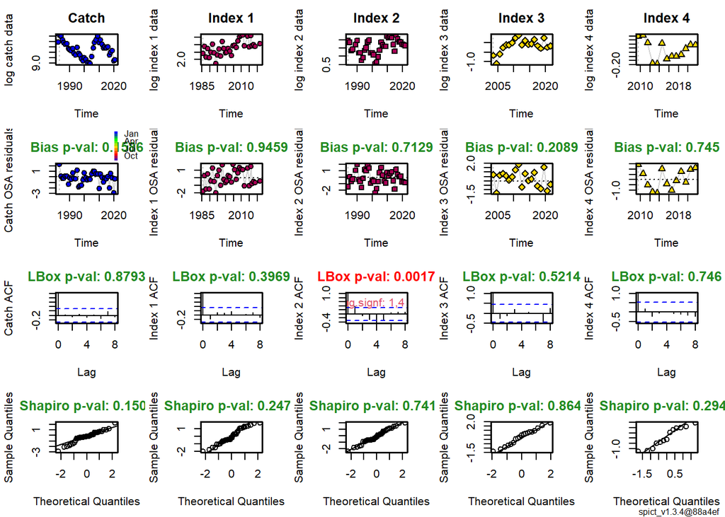

```r
r1 <- calc.osa.resid(res1)
plotspict.diagnostic(r1,lag.max =8)
```

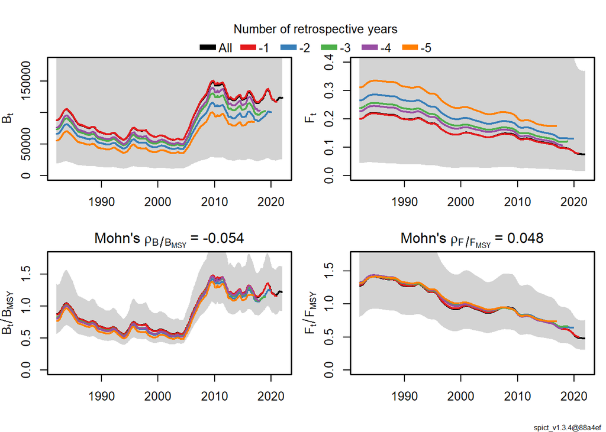

```
##       FFmsy       BBmsy
##  0.04840827 -0.05393025
```

```r
r1<- res1
rep1=retro(r1, nretroyear=5)
plotspict.retro(rep1)
```

```r
set.seed(1234)
a=check.ini(inp1, ntrials=5,verbose = FALSE)
```

[output not shown]

```r
a$check.ini$resmat
```

```
##         Distance        m        K  q  q  q  q    n  sdb  sdf  sdi  sdi  sdi
## Basevec     0.00 19350.32 151183.1  0  0  0  0 6.01 0.15 0.09 0.32 0.31 0.17
## Trial 1     0.16 19350.32 151183.2  0  0  0  0 6.01 0.15 0.09 0.32 0.31 0.17
## Trial 2     0.04 19350.32 151183.1  0  0  0  0 6.01 0.15 0.09 0.32 0.31 0.17
## Trial 3     0.00       NA       NA NA NA NA NA   NA   NA   NA   NA   NA   NA
## Trial 4     0.12 19350.32 151183.2  0  0  0  0 6.01 0.15 0.09 0.32 0.31 0.17
## Trial 5     0.28 19350.35 151183.3  0  0  0  0 6.01 0.15 0.09 0.32 0.31 0.17
##         sdi  sdc
## Basevec 0.1 0.06
## Trial 1 0.1 0.06
## Trial 2 0.1 0.06
## Trial 3  NA   NA
## Trial 4 0.1 0.06
## Trial 5 0.1 0.06
```

Confidence intervals of $F/F_{msy}$ and $B/B_{msy}$ estimates.

```r
fit=res1

get.par("logFmFmsy", fit, exp=TRUE, CI = 0.9)
```

```
##                  ll      est       ul       sd        cv
## logFmFmsy 0.3257184 0.478234 0.702164 0.233496 0.2367151
```

```r
get.par("logBmBmsy", fit, exp=TRUE, CI = 0.9)
```

```
##                 ll      est       ul       sd        cv
## logBmBmsy 0.963879 1.227585 1.563437 0.147027 0.1478252
```

AIC value:

```r
get.AIC(res1)
```

```
## [1] 60.59171
```

## 4.5 References

Pedersen, M.W. and Berg, C.W. (2017), A stochastic surplus production model in continuous time. Fish Fish, 18: 226-243. https://doi.org/10.1111/faf.12174

# 5 Known biomass production model (KBPM)

## 5.1 Description

An alternative line of research based on surplus production models named known-biomass production models (KBPM) was developed (MacCall, 2002) based on the idea that the annual surplus production in an unfished stock is equal to *B<sub>t+1</sub>-B<sub>t</sub>*, and that, for a fished stock, the calculation of surplus production depends on catch.

In contrast to the traditional SPMs, KBPMs use as input data a biomass time series produced by other stock assessment model instead of biomass index and thereby avoid the imprecision associated with estimating the catchability coefficient. Deep explanations can be found in the knobi package vignette.

## 5.2 Load package

```r
# Uncomment lines if necessary:
# remotes::install_github("MERVEX-group/knobi")
library(knobi)
```

## 5.3 Prepare input data

Loading data and control lists.

```r
# Same dataset as in "spict"
Database=input_catches

# We take the SSB, catches and years data series from our Database
data<-list()
data$Spawning_Biomass=Database$ssb_val
data$Catches=Database$catch
data$years=Database$years

# Now we define the control list.
control=list()
control$pella="TRUE" # Logical. TRUE means that Pella-Tomlinson model is used.
                     # FALSE means that Schaefer model is employed.
control$method="SSB" # Information for the fit: "SSB" or "Biomass".
```

## 5.4 Fit

Finally, we can fit the model

```r
knobi_results<-knobi_fit(data,control)
```

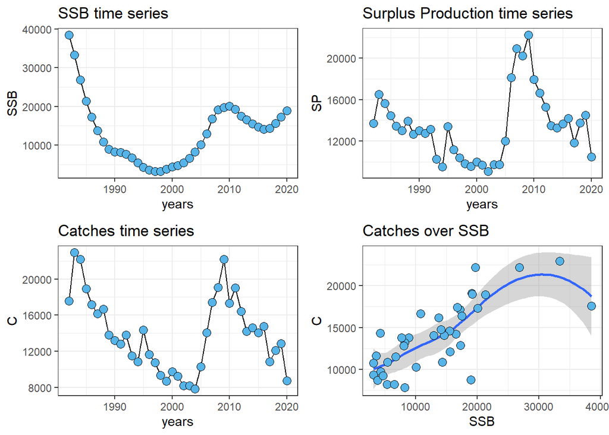

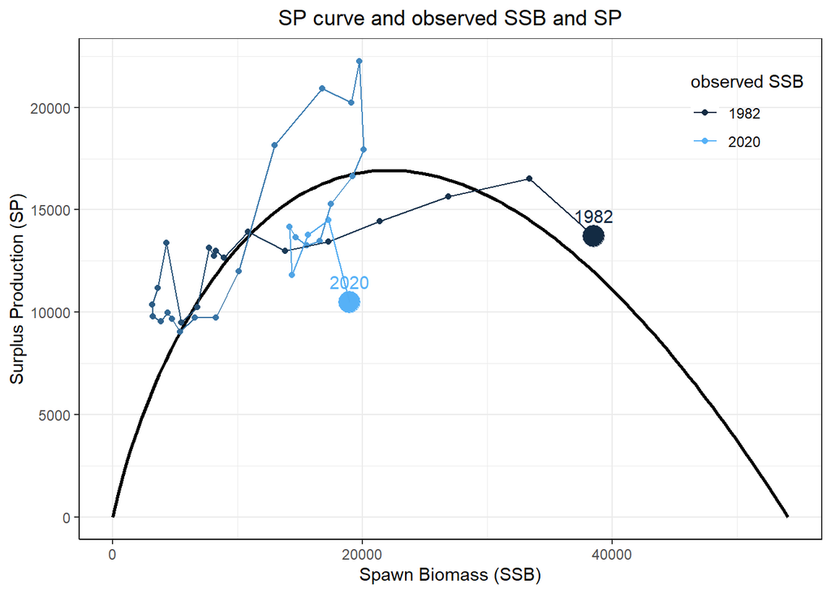

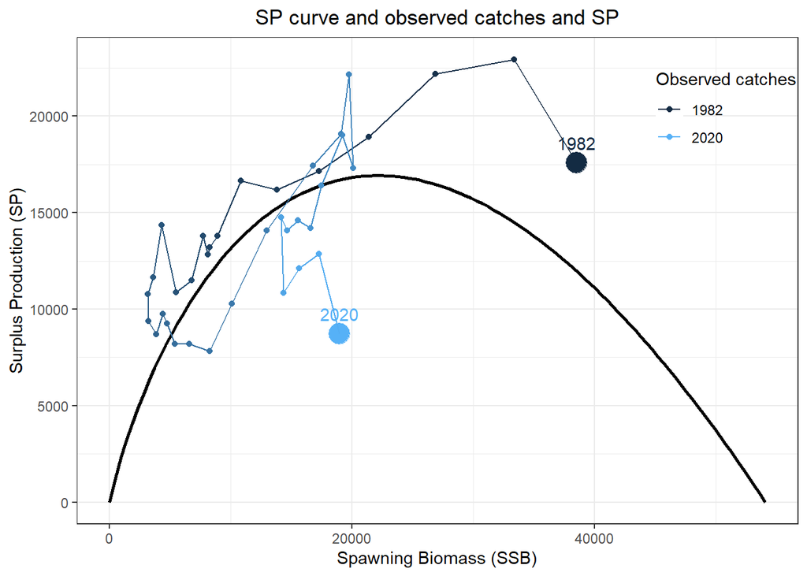

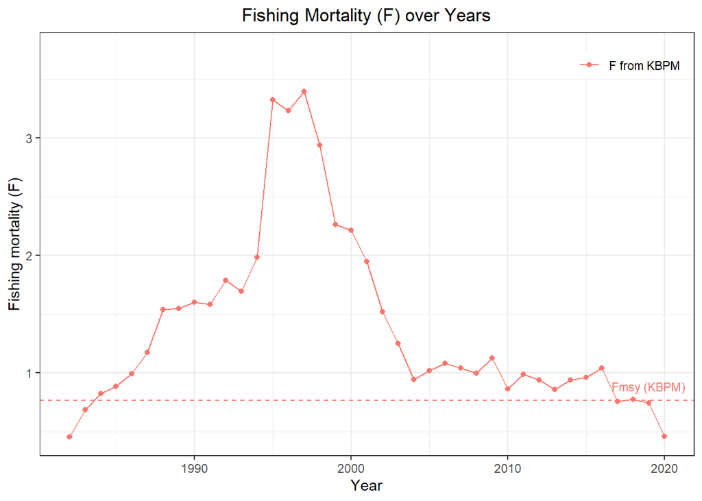

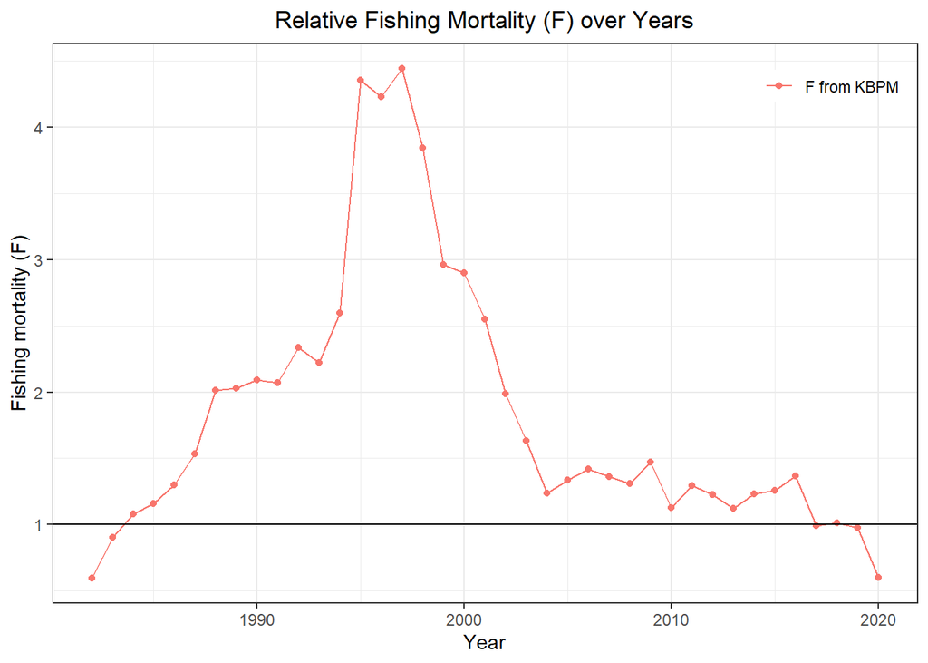

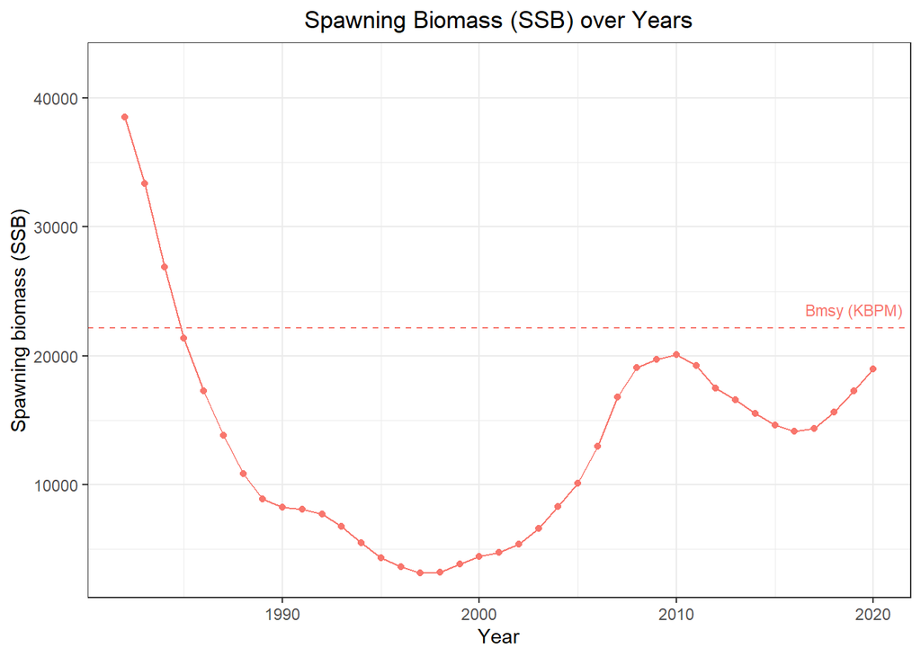

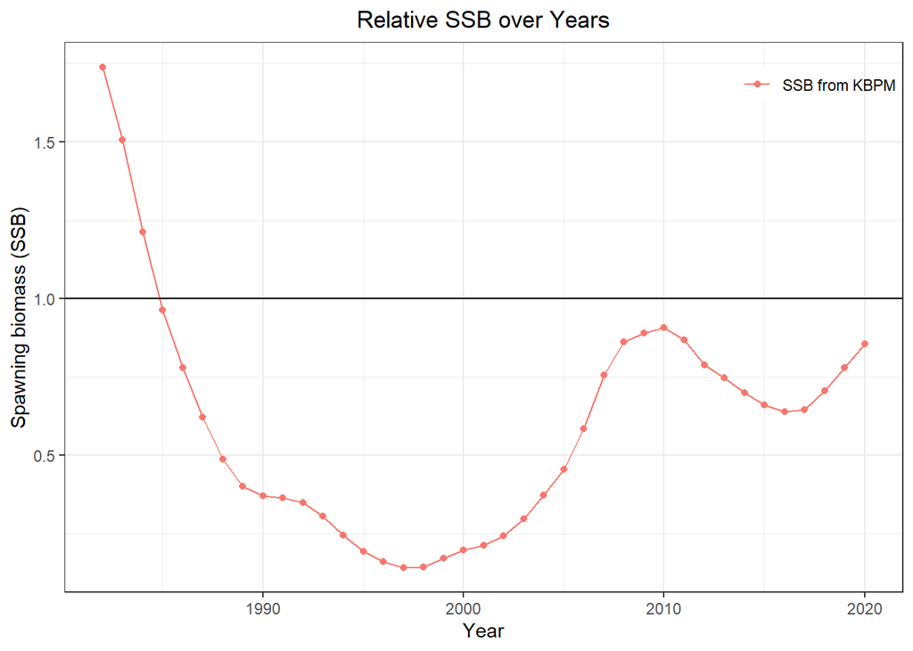

The quantitative results are shown in:

```r
knobi_results$fit
```

```
## $Parameter_estimates
##            r            K            p
##     0.955265 54079.553301     0.250000
##
## $data
## $data$SP
##  [1] 13706.409 16518.879 15652.226 14446.700 13433.100 12996.300 13912.500
##  [8] 12664.680 12998.260 12735.540 13131.270 10251.340  9492.826 13394.859
## [15] 11169.033 10374.520  9792.846  9561.117  9981.673  9685.851  9043.441
## [22]  9721.932  9718.965 11996.280 18136.700 20939.728 20243.425 22265.063
## [29] 17950.212 16638.896 15292.730 13474.090 13271.227 13658.927 14167.652
## [36] 11812.637 13764.384 14504.726 10472.904
##
## $data$SSB
##  [1] 38512.500 33354.100 26875.100 21364.350 17253.250 13794.950 10830.350
##  [8]  8899.440  8242.910  8101.310  7722.215  6770.020  5467.925  4311.395
## [15]  3602.585  3169.895  3187.270  3837.170  4394.720  4738.545  5387.570
## [22]  6572.915  8278.585 10085.090 12981.750 16770.450 19100.950 19725.450
## [29] 20090.500 19225.300 17488.050 16566.200 15524.950 14644.450 14140.950
## [36] 14329.700 15632.250 17273.600 18965.700
##
##
## $RP
## $RP$K
## [1] 54079.55
##
## $RP$B_MSY
## [1] 22150.99
##
## $RP$F_MSY
## [1] 0.764212
##
## $RP$MSY
## [1] 16928.05
##
## $RP$MSYoverK
## [1] 0.3130212
##
##
## $optimr
## $optimr$value
## [1] 292384501
##
## $optimr$convergence
## [1] 0
##
## $optimr$message
## [1] "CONVERGENCE: REL_REDUCTION_OF_F <= FACTR*EPSMCH"
##
##
## $error
##                 SER R-squared adj-R-squared      AIC     RMSE      MAPE
## KBPM_error 2849.876 0.2882524     0.2487109 623.3707 2738.072 0.1706431
##
## attr(,"class")
## [1] "Pella"
```

**Checklist for the acceptance of a KBPM assessment**

It is possible to make a retrospective analysis

```r
knobi_retrospectives<-knobi_retro(knobi_results,nR=5)
```

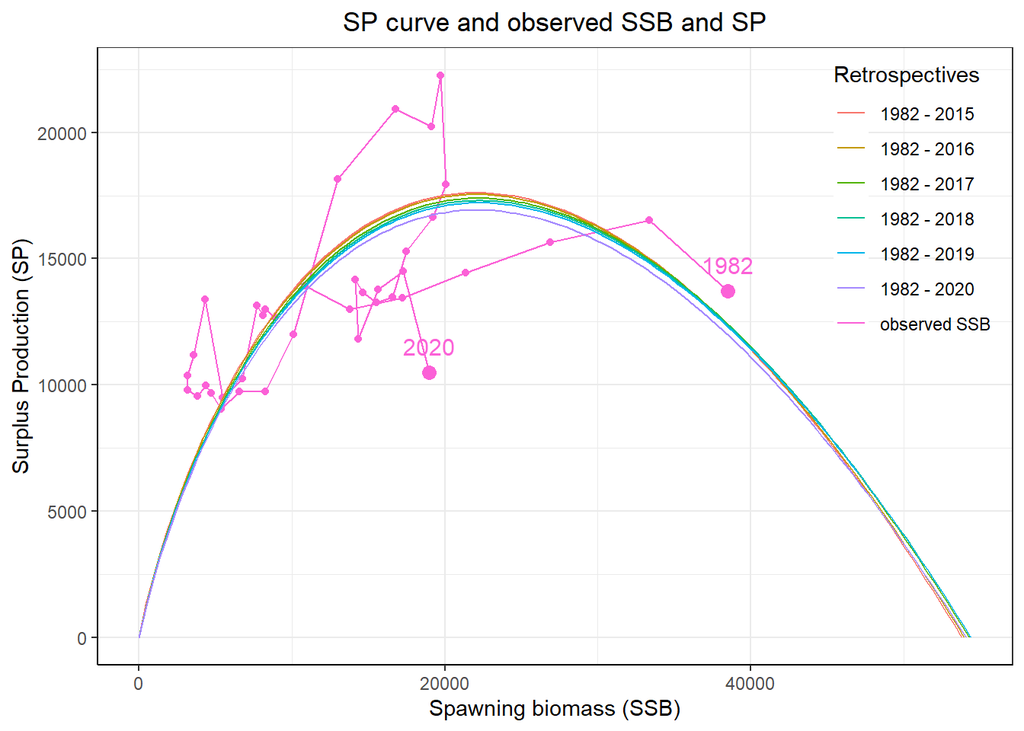

```r
knobi_retrospectives
```

```
## $`1982 - 2019`
## [[1]]
##            r            K            p
## 9.652639e-01 5.441384e+04 2.500000e-01
##
## attr(,"class")
## [1] "Pella"
##
## $`1982 - 2018`
## [[1]]
##            r            K            p
## 9.703229e-01 5.441200e+04 2.500000e-01
##
## attr(,"class")
## [1] "Pella"
##
## $`1982 - 2017`
## [[1]]
##            r            K            p
## 9.779277e-01 5.429078e+04 2.500000e-01
##
## attr(,"class")
## [1] "Pella"
##
## $`1982 - 2016`
## [[1]]
##            r            K            p
##     0.992415 53957.713360     0.250000
##
## attr(,"class")
## [1] "Pella"
##
## $`1982 - 2015`
## [[1]]
##            r            K            p
## 9.992154e-01 5.379978e+04 2.500000e-01
##
## attr(,"class")
## [1] "Pella"
##
## $RP
##                    K    B_MSY     F_MSY      MSY  MSYoverK
## 1982 - 2019 54413.84 22287.91 0.7722111 17210.97 0.3162977
## 1982 - 2018 54412.00 22287.15 0.7762583 17300.59 0.3179554
## 1982 - 2017 54290.78 22237.50 0.7823421 17397.34 0.3204473
## 1982 - 2016 53957.71 22101.08 0.7939320 17546.75 0.3251945
## 1982 - 2015 53799.78 22036.39 0.7993723 17615.28 0.3274229
```

## 5.5 References

MacCall, Alec. (2002). Use of Known-Biomass Production Models to Determine Productivity of West Coast Groundfish Stocks. North American Journal of Fisheries Management. 22. 272-279. DOI: 10.1577/1548-8675%282002%29022%3C0272%3AUOKBPM%3E2.0.CO%3B2.